# Chapter 4 - Clustering

Seppo Nyrkkö *Fri Nov 20, 2020*

## i. Load the Boston data from the MASS package.

```r
library(MASS)
```

## ii. The Boston data

is about housing values in the suburbs of Boston. It comes along with the R MASS data set collection.

*( Harrison, D. and Rubinfeld, D.L. (1978) Hedonic prices and the demand for clean air. J. Environ. Economics and Management 5, 81–102. – Belsley D.A., Kuh, E. and Welsch, R.E. (1980) Regression Diagnostics. Identifying Influential Data and Sources of Collinearity. New York: Wiley. )*

```r
# structure and the dimensions of the Boston data
data("Boston")
str(Boston)
```

```
## 'data.frame':    506 obs. of  14 variables:
##  $ crim   : num  0.00632 0.02731 0.02729 0.03237 0.06905 ...
##  $ zn     : num  18 0 0 0 0 0 12.5 12.5 12.5 12.5 ...
##  $ indus  : num  2.31 7.07 7.07 2.18 2.18 2.18 7.87 7.87 7.87 7.87 ...
##  $ chas   : int  0 0 0 0 0 0 0 0 0 0 ...
##  $ nox    : num  0.538 0.469 0.469 0.458 0.458 0.458 0.524 0.524 0.524 0.524 ...
##  $ rm     : num  6.58 6.42 7.18 7 7.15 ...
##  $ age    : num  65.2 78.9 61.1 45.8 54.2 58.7 66.6 96.1 100 85.9 ...
##  $ dis    : num  4.09 4.97 4.97 6.06 6.06 ...
##  $ rad    : int  1 2 2 3 3 3 5 5 5 5 ...
##  $ tax    : num  296 242 242 222 222 222 311 311 311 311 ...
##  $ ptratio: num  15.3 17.8 17.8 18.7 18.7 18.7 15.2 15.2 15.2 15.2 ...
##  $ black  : num  397 397 393 395 397 ...
##  $ lstat  : num  4.98 9.14 4.03 2.94 5.33 ...
##  $ medv   : num  24 21.6 34.7 33.4 36.2 28.7 22.9 27.1 16.5 18.9 ...
```

```r
summary(Boston)
```

```
##       crim                zn             indus            chas
##  Min.   : 0.00632   Min.   :  0.00   Min.   : 0.46   Min.   :0.00000
##  1st Qu.: 0.08204   1st Qu.:  0.00   1st Qu.: 5.19   1st Qu.:0.00000
##  Median : 0.25651   Median :  0.00   Median : 9.69   Median :0.00000
##  Mean   : 3.61352   Mean   : 11.36   Mean   :11.14   Mean   :0.06917
##  3rd Qu.: 3.67708   3rd Qu.: 12.50   3rd Qu.:18.10   3rd Qu.:0.00000
##  Max.   :88.97620   Max.   :100.00   Max.   :27.74   Max.   :1.00000
##       nox               rm             age              dis
##  Min.   :0.3850   Min.   :3.561   Min.   :  2.90   Min.   : 1.130
##  1st Qu.:0.4490   1st Qu.:5.886   1st Qu.: 45.02   1st Qu.: 2.100
##  Median :0.5380   Median :6.208   Median : 77.50   Median : 3.207
##  Mean   :0.5547   Mean   :6.285   Mean   : 68.57   Mean   : 3.795
##  3rd Qu.:0.6240   3rd Qu.:6.623   3rd Qu.: 94.08   3rd Qu.: 5.188
##  Max.   :0.8710   Max.   :8.780   Max.   :100.00   Max.   :12.127
##       rad              tax           ptratio          black
##  Min.   : 1.000   Min.   :187.0   Min.   :12.60   Min.   :  0.32
##  1st Qu.: 4.000   1st Qu.:279.0   1st Qu.:17.40   1st Qu.:375.38
##  Median : 5.000   Median :330.0   Median :19.05   Median :391.44
##  Mean   : 9.549   Mean   :408.2   Mean   :18.46   Mean   :356.67
##  3rd Qu.:24.000   3rd Qu.:666.0   3rd Qu.:20.20   3rd Qu.:396.23
##  Max.   :24.000   Max.   :711.0   Max.   :22.00   Max.   :396.90
##      lstat            medv
##  Min.   : 1.73   Min.   : 5.00
##  1st Qu.: 6.95   1st Qu.:17.02
##  Median :11.36   Median :21.20
##  Mean   :12.65   Mean   :22.53
##  3rd Qu.:16.95   3rd Qu.:25.00
##  Max.   :37.97   Max.   :50.00
```

506 obs with 14 variables. All numerical.

## iii. Graphical analysis

[figure not shown]

```r
# let's take only a sample, this takes some cpu cycles and produces a grid of tiny plots
ggpairs(Boston[sample(seq(1,nrow(Boston)),size=50),])
```

Some correlation can be seen in the scatter plots. Few distributions are normal, most are skewed or “double-bumped”, meaning there are clusters inside the variables.

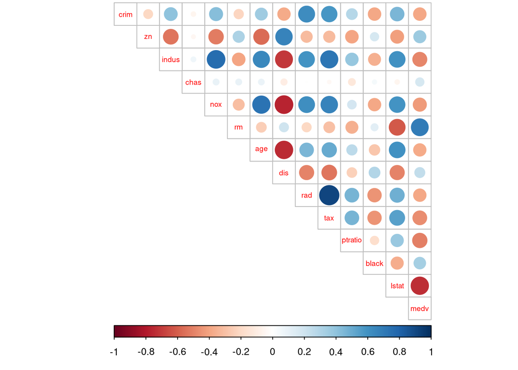

```r
# let us try the cor() matrix and corrplot()
cor_matrix <- cor(Boston)
corrplot(cor_matrix, method="circle", type="upper", cl.pos="b", tl.pos="d", tl.cex=0.6)
```

The correlation plot shows a few interesting positive correlations (radial highways and property tax, nitrogen oxides and industrial acres) and negative correlations (between industrial acres and distance to central areas; and median home values and lower status of population). Seems quite ok.

## iv. Normalize the dataset

```r
# print out summaries of the scaled data.

boston_sc <- as.data.frame(scale(Boston))

summary(boston_sc)
```

```
##       crim                 zn               indus              chas
##  Min.   :-0.419367   Min.   :-0.48724   Min.   :-1.5563   Min.   :-0.2723
##  1st Qu.:-0.410563   1st Qu.:-0.48724   1st Qu.:-0.8668   1st Qu.:-0.2723
##  Median :-0.390280   Median :-0.48724   Median :-0.2109   Median :-0.2723
##  Mean   : 0.000000   Mean   : 0.00000   Mean   : 0.0000   Mean   : 0.0000
##  3rd Qu.: 0.007389   3rd Qu.: 0.04872   3rd Qu.: 1.0150   3rd Qu.:-0.2723
##  Max.   : 9.924110   Max.   : 3.80047   Max.   : 2.4202   Max.   : 3.6648
##       nox                rm               age               dis
##  Min.   :-1.4644   Min.   :-3.8764   Min.   :-2.3331   Min.   :-1.2658
##  1st Qu.:-0.9121   1st Qu.:-0.5681   1st Qu.:-0.8366   1st Qu.:-0.8049
##  Median :-0.1441   Median :-0.1084   Median : 0.3171   Median :-0.2790
##  Mean   : 0.0000   Mean   : 0.0000   Mean   : 0.0000   Mean   : 0.0000
##  3rd Qu.: 0.5981   3rd Qu.: 0.4823   3rd Qu.: 0.9059   3rd Qu.: 0.6617
##  Max.   : 2.7296   Max.   : 3.5515   Max.   : 1.1164   Max.   : 3.9566
##       rad               tax             ptratio            black
##  Min.   :-0.9819   Min.   :-1.3127   Min.   :-2.7047   Min.   :-3.9033
##  1st Qu.:-0.6373   1st Qu.:-0.7668   1st Qu.:-0.4876   1st Qu.: 0.2049
##  Median :-0.5225   Median :-0.4642   Median : 0.2746   Median : 0.3808
##  Mean   : 0.0000   Mean   : 0.0000   Mean   : 0.0000   Mean   : 0.0000
##  3rd Qu.: 1.6596   3rd Qu.: 1.5294   3rd Qu.: 0.8058   3rd Qu.: 0.4332
##  Max.   : 1.6596   Max.   : 1.7964   Max.   : 1.6372   Max.   : 0.4406
##      lstat              medv
##  Min.   :-1.5296   Min.   :-1.9063
##  1st Qu.:-0.7986   1st Qu.:-0.5989
##  Median :-0.1811   Median :-0.1449
##  Mean   : 0.0000   Mean   : 0.0000
##  3rd Qu.: 0.6024   3rd Qu.: 0.2683
##  Max.   : 3.5453   Max.   : 2.9865
```

The means are all zero as expected. There is also the unit variance per each variable.

Now let’s calculate the crime quantiles (from the scaled crime rate).

```r
bins = quantile(boston_sc$crim)
bins
```

```
##           0%          25%          50%          75%         100%
## -0.419366929 -0.410563278 -0.390280295  0.007389247  9.924109610
```

```r
labels = c("low", "med_low", "med_high", "high")
crime <- cut(boston_sc$crim,
             breaks=bins,
             labels=labels,
             include.lowest=TRUE)
boston_sc <- dplyr::select(boston_sc, -crim)
boston_sc <- data.frame(boston_sc, crime)
str(boston_sc)
```

```
## 'data.frame':    506 obs. of  14 variables:
##  $ zn     : num  0.285 -0.487 -0.487 -0.487 -0.487 ...
##  $ indus  : num  -1.287 -0.593 -0.593 -1.306 -1.306 ...
##  $ chas   : num  -0.272 -0.272 -0.272 -0.272 -0.272 ...
##  $ nox    : num  -0.144 -0.74 -0.74 -0.834 -0.834 ...
##  $ rm     : num  0.413 0.194 1.281 1.015 1.227 ...
##  $ age    : num  -0.12 0.367 -0.266 -0.809 -0.511 ...
##  $ dis    : num  0.14 0.557 0.557 1.077 1.077 ...
##  $ rad    : num  -0.982 -0.867 -0.867 -0.752 -0.752 ...
##  $ tax    : num  -0.666 -0.986 -0.986 -1.105 -1.105 ...
##  $ ptratio: num  -1.458 -0.303 -0.303 0.113 0.113 ...
##  $ black  : num  0.441 0.441 0.396 0.416 0.441 ...
##  $ lstat  : num  -1.074 -0.492 -1.208 -1.36 -1.025 ...
##  $ medv   : num  0.16 -0.101 1.323 1.182 1.486 ...
##  $ crime  : Factor w/ 4 levels "low","med_low",..: 1 1 1 1 1 1 2 2 2 2 ...
```

We have a crime factor, great. Now dividing the dataset to train and test sets: 80% goes in training

```r
ind <- sample(seq(1,nrow(boston_sc)), size=nrow(boston_sc) * 0.8)
train <- boston_sc[ind,]
test <- boston_sc[-ind,]
str(train)
```

```
## 'data.frame':    404 obs. of  14 variables:
##  $ zn     : num  -0.487 -0.487 -0.487 -0.487 -0.487 ...
##  $ indus  : num  1.015 1.015 1.015 -0.616 1.015 ...
##  $ chas   : num  -0.272 -0.272 -0.272 -0.272 -0.272 ...
##  $ nox    : num  1.194 1.858 0.9 -0.921 1.366 ...
##  $ rm     : num  -0.616 0.161 -0.963 -0.105 0.593 ...
##  $ age    : num  0.328 0.69 1.116 -2.205 0.761 ...
##  $ dis    : num  -1.09 -0.606 -1.192 0.915 -0.569 ...
##  $ rad    : num  1.66 1.66 1.66 -0.752 1.66 ...
##  $ tax    : num  1.53 1.53 1.53 -1.04 1.53 ...
##  $ ptratio: num  0.806 0.806 0.806 -0.257 0.806 ...
##  $ black  : num  -0.203 0.196 -0.269 0.414 -1.111 ...
##  $ lstat  : num  2.425 -0.681 -0.0732 -0.73 0.5275 ...
##  $ medv   : num  -1.765 0.268 0.584 0.236 -0.667 ...
##  $ crime  : Factor w/ 4 levels "low","med_low",..: 4 4 4 2 4 4 1 1 3 2 ...
```

```r
dim(train)
```

```
## [1] 404  14
```

```r
dim(test)
```

```
## [1] 102  14
```

train and test sets seem OK.

## v. LDA on the train

Using the categorical crime rate as target variable. Other variables as predictor variables.

```r
model = lda(crime ~ ., data=train)
model
```

```
## Call:
## lda(crime ~ ., data = train)
##
## Prior probabilities of groups:
##       low   med_low  med_high      high
## 0.2698020 0.2450495 0.2400990 0.2450495
##
## Group means:
##                   zn      indus         chas        nox          rm        age
## low       0.96586203 -0.9482339 -0.091728139 -0.9035993  0.42637249 -0.9106449
## med_low  -0.08770323 -0.3170480  0.006051757 -0.6188964 -0.05935678 -0.4476616
## med_high -0.37938430  0.1955994  0.174146217  0.4504020  0.18350338  0.4267571
## high     -0.48724019  1.0171737 -0.073485621  1.0363758 -0.35119496  0.8027972
##                 dis        rad        tax    ptratio      black       lstat
## low       0.9513779 -0.6942276 -0.7343195 -0.4532316  0.3775628 -0.77523475
## med_low   0.3979356 -0.5468458 -0.4892054 -0.1110338  0.3186490 -0.20073588
## med_high -0.3885211 -0.3993498 -0.2960591 -0.3385088  0.0811790 -0.06917614
## high     -0.8417273  1.6375616  1.5136504  0.7801170 -0.8439287  0.87138212
##                 medv
## low       0.51564308
## med_low   0.03542197
## med_high  0.20391648
## high     -0.71591247
##
## Coefficients of linear discriminants:
##                 LD1           LD2         LD3
## zn       0.09544082  0.4801383981 -0.98108224
## indus    0.03960886 -0.3538622853  0.44064622
## chas    -0.09636621  0.0001249633  0.13935599
## nox      0.35826051 -0.8251865865 -1.32009887
## rm      -0.08368620 -0.1220293544 -0.03132481
## age      0.27342604 -0.3689472409 -0.31396011
## dis     -0.11331200 -0.1206774981  0.01842425
## rad      3.11358089  0.8805060827 -0.18094742
## tax      0.04948816  0.1764983751  0.47387219
## ptratio  0.12198517 -0.0045279706 -0.32568772
## black   -0.11880870  0.0251018387  0.13890241
## lstat    0.20158224 -0.0179870848  0.61549382
## medv     0.18882325 -0.3217557044 -0.13155655
##
## Proportion of trace:
##    LD1    LD2    LD3
## 0.9439 0.0411 0.0150
```

Draw the LDA (bi)plot. Use color from the crime factor index.

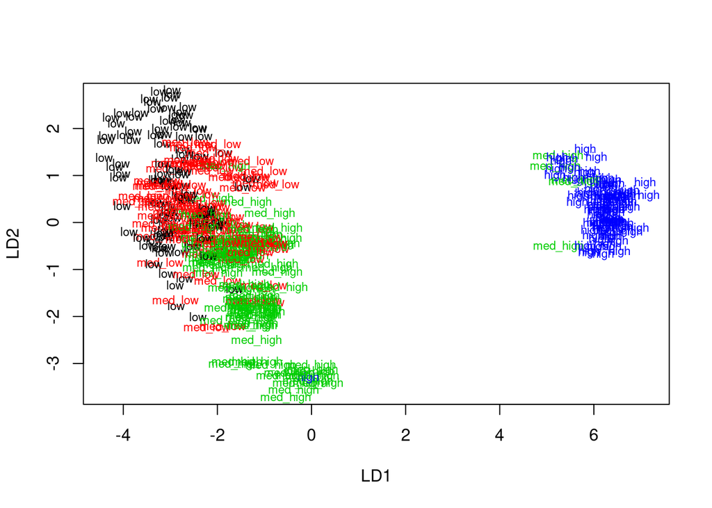

```r
classes = as.numeric(train$crime)
plot(model, dimen=2, col=classes, pch=classes)
```

Seems like the highest crime quantile is separable from other clusters. We can proceed to the model testing part.

## vi. Testing the prediction

```r
# remove the crime factor from the test set
correct_classes = test$crime
test <- dplyr::select(test, -crime)
str(correct_classes)
```

```
##  Factor w/ 4 levels "low","med_low",..: 2 2 3 3 3 3 2 2 2 2 ...
```

```r
str(test)
```

```
## 'data.frame':    102 obs. of  13 variables:
##  $ zn     : num  0.0487 0.0487 -0.4872 -0.4872 -0.4872 ...
##  $ indus  : num  -0.476 -0.476 -0.437 -0.437 -0.437 ...
##  $ chas   : num  -0.272 -0.272 -0.272 -0.272 -0.272 ...
##  $ nox    : num  -0.265 -0.265 -0.144 -0.144 -0.144 ...
##  $ rm     : num  -0.93 -0.392 -0.268 -0.419 -1.017 ...
##  $ age    : num  1.116 0.509 0.566 0.466 1.049 ...
##  $ dis    : num  1.08612 1.15479 0.31669 0.21981 0.00136 ...
##  $ rad    : num  -0.522 -0.522 -0.637 -0.637 -0.637 ...
##  $ tax    : num  -0.577 -0.577 -0.601 -0.601 -0.601 ...
##  $ ptratio: num  -1.5 -1.5 1.18 1.18 1.18 ...
##  $ black  : num  0.328 0.441 0.256 0.329 0.218 ...
##  $ lstat  : num  2.4194 0.0864 -0.3351 0.2824 1.1717 ...
##  $ medv   : num  -0.656 -0.395 -0.471 -0.547 -0.971 ...
```

Test doesn’t have the correct answer - ok

Prediction of crime categories with LDA using the prepared test data:

```r
predictions = predict(model, newdata=test)

# Cross tabulate the results with the crime categories from the test set.
table(correct=correct_classes, predicted=predictions$class)
```

```
##           predicted
## correct    low med_low med_high high
##   low        9       6        3    0
##   med_low    3      14       10    0
##   med_high   1      11       16    1
##   high       0       0        0   28
```

## vii. k-means

Let’s reload and standardize the Boston dataset

```r
data("Boston")

# Scale the variables to mean zero and unit variance

boston_sc <- as.data.frame(scale(Boston))

# This is one of my favorite methods in R. (besides the heatmap)

dist_eu <- dist(boston_sc, method="euclidean")
summary(dist_eu)
```

```
##    Min. 1st Qu.  Median    Mean 3rd Qu.    Max.
##  0.1343  3.4625  4.8241  4.9111  6.1863 14.3970
```

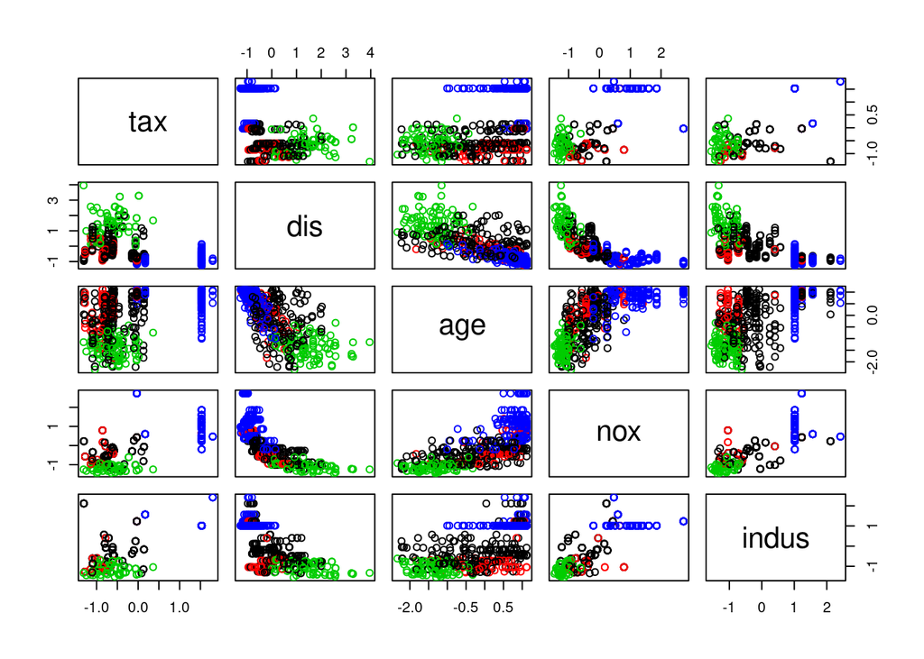

```r
# Running k-means algorithm on the dataset.
# What is the optimal number of clusters? Try 4 ...

km <- kmeans(boston_sc, centers=4)

# Visualize the with a few variables as pairs
pairs(boston_sc[c('tax','dis','age',
                  'nox','indus')], col=km$cluster)
```

Ok.

Seems like there are some clusters found, since we see some connection between the cluster color and the xy-position on the plot.

Let’s run the k-means again to find an optimal number of k clusters.

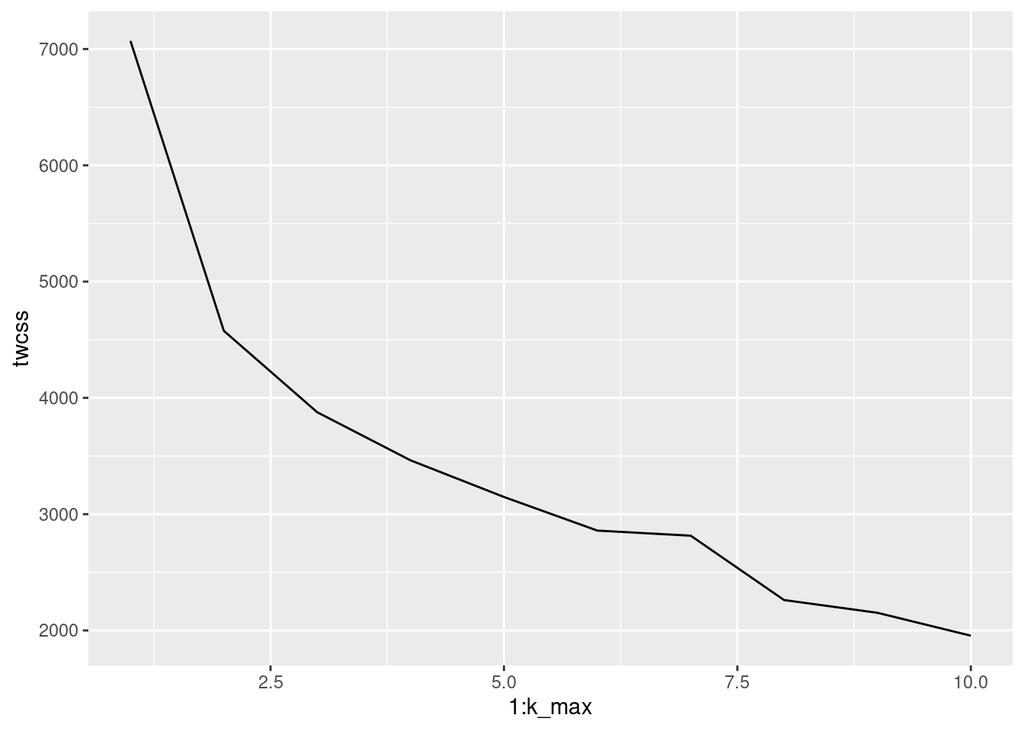

```r
# boston_sc dataset is available
set.seed(123)

# determine the number of clusters
k_max <- 10

# calculate the total within sum of squares
twcss <- sapply(1:k_max, function(k){kmeans(boston_sc, k)$tot.withinss})

# visualize the results
qplot(x = 1:k_max, y = twcss, geom = 'line')
```

Seems like there is a drop at 2 clusters.

Let us do the clustering again with centers=2

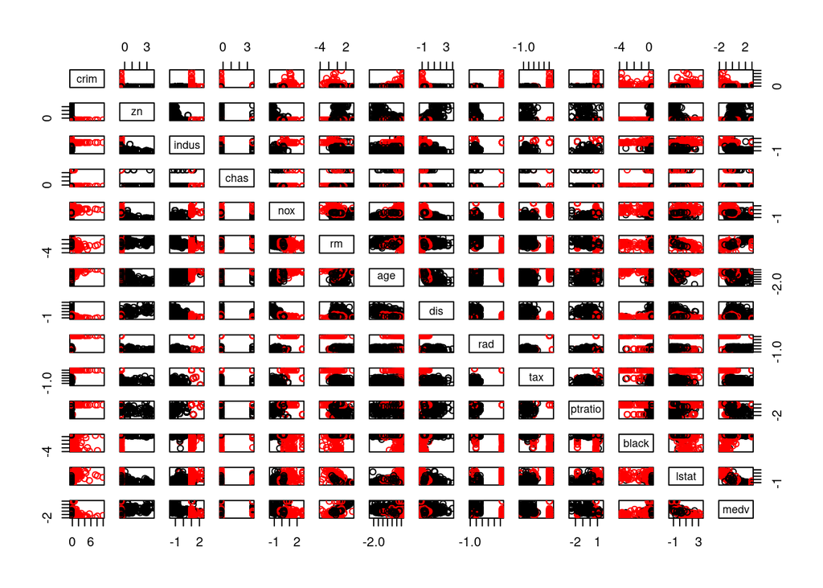

```r
# k-means clustering
km <-kmeans(boston_sc, centers = 2)


# plot the Boston dataset with clusters
pairs(boston_sc, col=km$cluster)
```

Seems to be pretty ok. For a better picture, let’s look at the pairs data with the same variables as before:

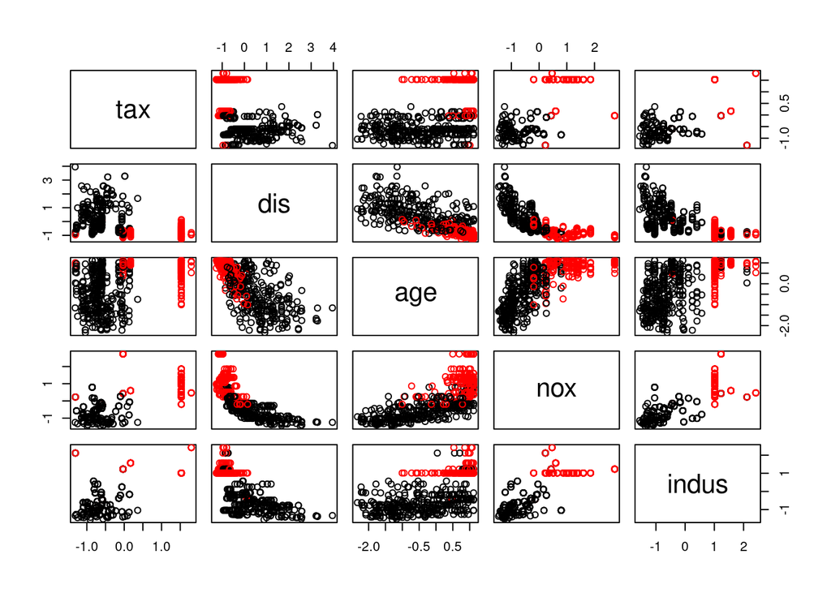

```r
# plot the Boston dataset with clusters
pairs(boston_sc[c('tax','dis','age',
                  'nox','indus')], col=km$cluster)
```

We can be pretty happy with this. There are two distinct clusters. Some bleeding can still be seen, in some pairs but the other dimensions show very distinct split between the clusters.

## extra: Arrows

```r
# Reload the original Boston dataset
data("Boston")

# Scale the variables  again to normalized

boston_sc <- as.data.frame(scale(Boston))

set.seed(123)

# 3 clusters using k-means for targets
km <- kmeans(boston_sc, centers=3)

#  LDA using the km clusters
lda.fit <- lda(x=boston_sc, grouping=km$cluster)

# Examine the object
lda.fit
```

```
## Call:
## lda(boston_sc, grouping = km$cluster)
##
## Prior probabilities of groups:
##         1         2         3
## 0.2806324 0.3992095 0.3201581
##
## Group means:
##         crim         zn        indus        chas         nox         rm
## 1  0.9693718 -0.4872402  1.074440092 -0.02279455  1.04197430 -0.4146077
## 2 -0.3549295 -0.4039269  0.009294842  0.11748284  0.01531993 -0.2547135
## 3 -0.4071299  0.9307491 -0.953383032 -0.12651054 -0.93243813  0.6810272
##          age        dis        rad        tax     ptratio      black
## 1  0.7666895 -0.8346743  1.5010821  1.4852884  0.73584205 -0.7605477
## 2  0.3096462 -0.2267757 -0.5759279 -0.4964651 -0.09219308  0.2473725
## 3 -1.0581385  1.0143978 -0.5976310 -0.6828704 -0.53004055  0.3582008
##         lstat       medv
## 1  0.85963373 -0.6874933
## 2  0.09168925 -0.1052456
## 3 -0.86783467  0.7338497
##
## Coefficients of linear discriminants:
##                 LD1         LD2
## crim     0.03654114  0.20373943
## zn      -0.08346821  0.34784463
## indus   -0.32262409 -0.12105014
## chas    -0.04761479 -0.13327215
## nox     -0.13026254  0.15610984
## rm       0.13267423  0.44058946
## age     -0.11936644 -0.84880847
## dis      0.23454618  0.58819732
## rad     -1.96894437  0.57933028
## tax     -1.10861600  0.53984421
## ptratio -0.13087741 -0.02004405
## black    0.15432491 -0.06106305
## lstat   -0.14002173  0.14786473
## medv     0.02559139  0.37307811
##
## Proportion of trace:
##    LD1    LD2
## 0.8999 0.1001
```

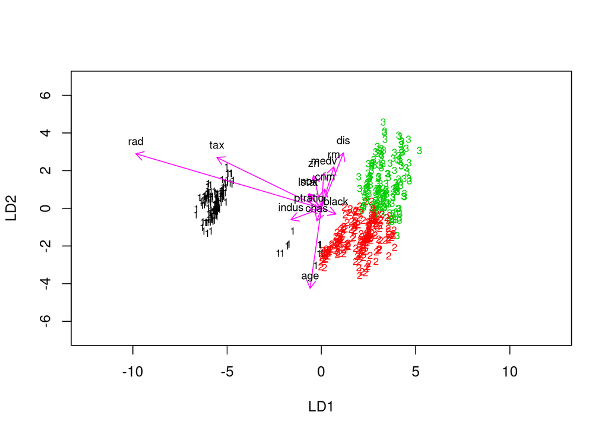

```r
# now with arrows as in the datacamp task
lda.arrows <- function(x, myscale = 1, arrow_heads = 0.1,
                       color = "magenta", tex = 0.75, choices = c(1,2))
  {
  heads <- coef(x)
  arrows(x0 = 0, y0 = 0,
         x1 = myscale * heads[,choices[1]],
         y1 = myscale * heads[,choices[2]], col=color, length = arrow_heads)
  text(jitter(myscale * heads[,choices]), labels = row.names(heads),
       cex = tex, col="black", pos=3)
}

# Plot with arrows
plot(lda.fit, dimen = 2, col=km$cluster, pch=km$cluster, ylim=c(-7,7),xlim=c(-10,10))
lda.arrows(lda.fit, myscale = 5)
```

Two possible separate clusters could be explained by: i) high value homes and large lots (by surface area) and ii) the closeness to radial highways.

This clustering seems very appropriate, and we can be happy with this.